# Clasificacion de churn de producto bancario

Llorenç Noguera

5/5/2020

# Problema de clasificación

Nos encontramos ante un dataset de una entidad bancaria portuguesa con información a una campaña de marketing. El objetivo es tratar de identificar si el cliente está suscrito a un producto bancario o no.

## 1. Carga de librerias y de dataset

Nos vamos ayudar de las siguientes librerias

```r
library(tidyverse)
library(caret)
library(GGally)
library(tidymodels)
library(skimr)
library(fastICA)
library(moments)
library(corrplot)
library(themis)
library(kernlab)
library(igraph)
```

Cargamos el dataset

```r
df <- read.csv("bank-full.csv", header = T, sep = ";", stringsAsFactors = T)
```

## 2. Analisis exploratorio

Como podemos observar, el dataset consta de 45k observacion y 17 variables.

```r
str(df)
```

```
## 'data.frame':    45211 obs. of  17 variables:
##  $ age      : int  58 44 33 47 33 35 28 42 58 43 ...
##  $ job      : Factor w/ 12 levels "admin.","blue-collar",..: 5 10 3 2 12 5 5 3 6 10 ...
##  $ marital  : Factor w/ 3 levels "divorced","married",..: 2 3 2 2 3 2 3 1 2 3 ...
##  $ education: Factor w/ 4 levels "primary","secondary",..: 3 2 2 4 4 3 3 3 1 2 ...
##  $ default  : Factor w/ 2 levels "no","yes": 1 1 1 1 1 1 1 2 1 1 ...
##  $ balance  : int  2143 29 2 1506 1 231 447 2 121 593 ...
##  $ housing  : Factor w/ 2 levels "no","yes": 2 2 2 2 1 2 2 2 2 2 ...
##  $ loan     : Factor w/ 2 levels "no","yes": 1 1 2 1 1 1 2 1 1 1 ...
##  $ contact  : Factor w/ 3 levels "cellular","telephone",..: 3 3 3 3 3 3 3 3 3 3 ...
##  $ day      : int  5 5 5 5 5 5 5 5 5 5 ...
##  $ month    : Factor w/ 12 levels "apr","aug","dec",..: 9 9 9 9 9 9 9 9 9 9 ...
##  $ duration : int  261 151 76 92 198 139 217 380 50 55 ...
##  $ campaign : int  1 1 1 1 1 1 1 1 1 1 ...
##  $ pdays    : int  -1 -1 -1 -1 -1 -1 -1 -1 -1 -1 ...
##  $ previous : int  0 0 0 0 0 0 0 0 0 0 ...
##  $ poutcome : Factor w/ 4 levels "failure","other",..: 4 4 4 4 4 4 4 4 4 4 ...
##  $ y        : Factor w/ 2 levels "no","yes": 1 1 1 1 1 1 1 1 1 1 ...
```

```r
summary(df)
```

```
##       age                 job           marital          education
##  Min.   :18.00   blue-collar:9732   divorced: 5207   primary  : 6851
##  1st Qu.:33.00   management :9458   married :27214   secondary:23202
##  Median :39.00   technician :7597   single  :12790   tertiary :13301
##  Mean   :40.94   admin.     :5171                    unknown  : 1857
##  3rd Qu.:48.00   services   :4154
##  Max.   :95.00   retired    :2264
##                  (Other)    :6835
##  default        balance       housing      loan            contact
##  no :44396   Min.   : -8019   no :20081   no :37967   cellular :29285
##  yes:  815   1st Qu.:    72   yes:25130   yes: 7244   telephone: 2906
##              Median :   448                           unknown  :13020
##              Mean   :  1362
##              3rd Qu.:  1428
##              Max.   :102127
##
##       day            month          duration         campaign
##  Min.   : 1.00   may    :13766   Min.   :   0.0   Min.   : 1.000
##  1st Qu.: 8.00   jul    : 6895   1st Qu.: 103.0   1st Qu.: 1.000
##  Median :16.00   aug    : 6247   Median : 180.0   Median : 2.000
##  Mean   :15.81   jun    : 5341   Mean   : 258.2   Mean   : 2.764
##  3rd Qu.:21.00   nov    : 3970   3rd Qu.: 319.0   3rd Qu.: 3.000
##  Max.   :31.00   apr    : 2932   Max.   :4918.0   Max.   :63.000
##                  (Other): 6060
##      pdays          previous           poutcome       y
##  Min.   : -1.0   Min.   :  0.0000   failure: 4901   no :39922
##  1st Qu.: -1.0   1st Qu.:  0.0000   other  : 1840   yes: 5289
##  Median : -1.0   Median :  0.0000   success: 1511
##  Mean   : 40.2   Mean   :  0.5803   unknown:36959
##  3rd Qu.: -1.0   3rd Qu.:  0.0000
##  Max.   :871.0   Max.   :275.0000
##
```

```r
skim(df)
```

Data summary

| Name | df |
| --- | --- |
| Number of rows | 45211 |
| Number of columns | 17 |
| _______________________ |  |
| Column type frequency: |  |
| factor | 10 |
| numeric | 7 |
| ________________________ |  |
| Group variables | None |

**Variable type: factor**

| skim_variable | n_missing | complete_rate | ordered | n_unique | top_counts |
| --- | --- | --- | --- | --- | --- |
| job | 0 | 1 | FALSE | 12 | blu: 9732, man: 9458, tec: 7597, adm: 5171 |
| marital | 0 | 1 | FALSE | 3 | mar: 27214, sin: 12790, div: 5207 |
| education | 0 | 1 | FALSE | 4 | sec: 23202, ter: 13301, pri: 6851, unk: 1857 |
| default | 0 | 1 | FALSE | 2 | no: 44396, yes: 815 |
| housing | 0 | 1 | FALSE | 2 | yes: 25130, no: 20081 |
| loan | 0 | 1 | FALSE | 2 | no: 37967, yes: 7244 |
| contact | 0 | 1 | FALSE | 3 | cel: 29285, unk: 13020, tel: 2906 |
| month | 0 | 1 | FALSE | 12 | may: 13766, jul: 6895, aug: 6247, jun: 5341 |
| poutcome | 0 | 1 | FALSE | 4 | unk: 36959, fai: 4901, oth: 1840, suc: 1511 |
| y | 0 | 1 | FALSE | 2 | no: 39922, yes: 5289 |

**Variable type: numeric**

| skim_variable | n_missing | complete_rate | mean | sd | p0 | p25 | p50 | p75 | p100 | hist |
| --- | --- | --- | --- | --- | --- | --- | --- | --- | --- | --- |
| age | 0 | 1 | 40.94 | 10.62 | 18 | 33 | 39 | 48 | 95 | ▅▇▃▁▁ |
| balance | 0 | 1 | 1362.27 | 3044.77 | -8019 | 72 | 448 | 1428 | 102127 | ▇▁▁▁▁ |
| day | 0 | 1 | 15.81 | 8.32 | 1 | 8 | 16 | 21 | 31 | ▇▆▇▆▆ |
| duration | 0 | 1 | 258.16 | 257.53 | 0 | 103 | 180 | 319 | 4918 | ▇▁▁▁▁ |
| campaign | 0 | 1 | 2.76 | 3.10 | 1 | 1 | 2 | 3 | 63 | ▇▁▁▁▁ |
| pdays | 0 | 1 | 40.20 | 100.13 | -1 | -1 | -1 | -1 | 871 | ▇▁▁▁▁ |
| previous | 0 | 1 | 0.58 | 2.30 | 0 | 0 | 0 | 0 | 275 | ▇▁▁▁▁ |

Pasamos a graficar histogramas y boxplots para hacernos una idea visual de la forma de los datos con los que vamos a trabajar. Vemos que en las variables numéricas hay mucha asimetría, problema que deberemos corregir. En la parte de las categóricas, vemos que hay variables que tienen muchos niveles, algunos de los cuales tienen poca frecuencia o son redundantes, problema que también debe corregirse. Por la parte de la variable dependiente tambén deberemos de llevar algún tipo de acción para corregir su problema de desbalanceo.

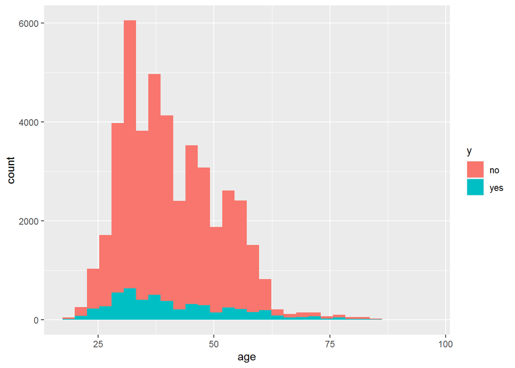

```r
ggplot(df, aes(x = age))+geom_histogram(aes(fill = y))
```

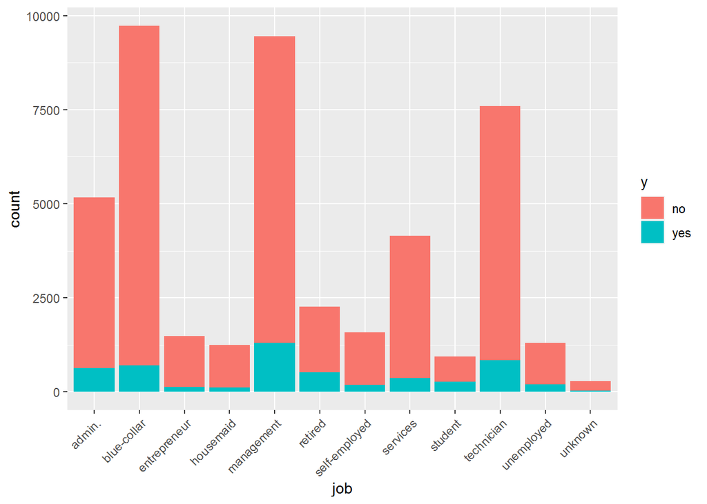

```r
ggplot(df, aes(x = job))+geom_histogram(aes(fill = y), stat = "count")+theme(axis.text.x = element_text(angle = 45, hjust = 1))
```

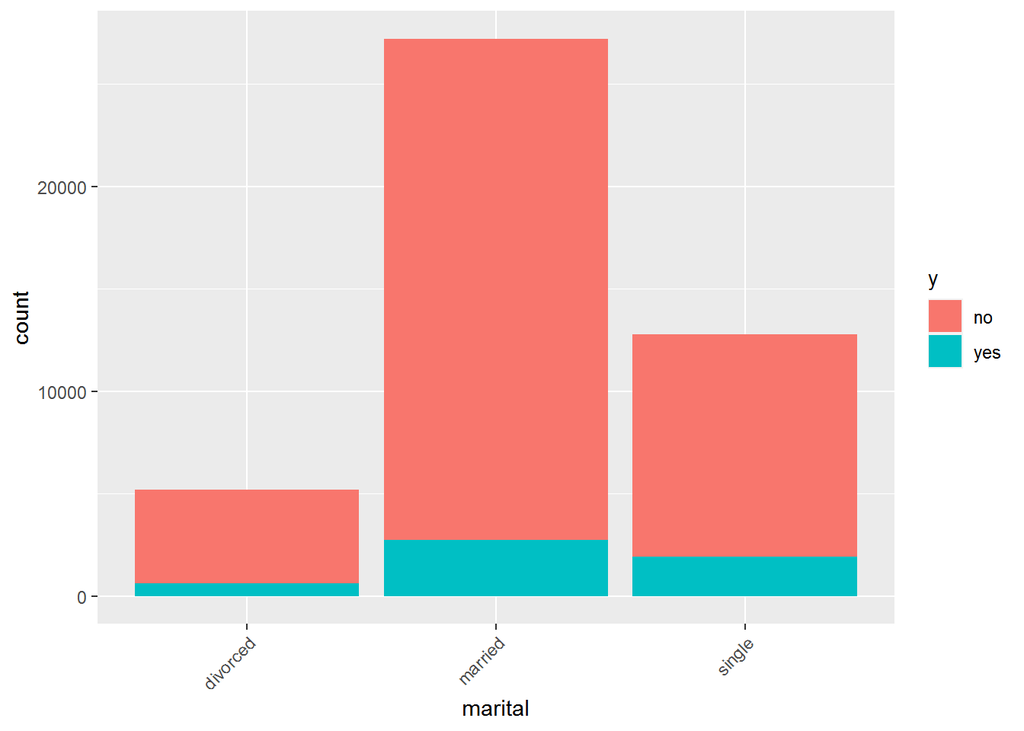

```r
ggplot(df, aes(x = marital))+geom_histogram(aes(fill = y), stat = "count")+theme(axis.text.x = element_text(angle = 45, hjust = 1))
```

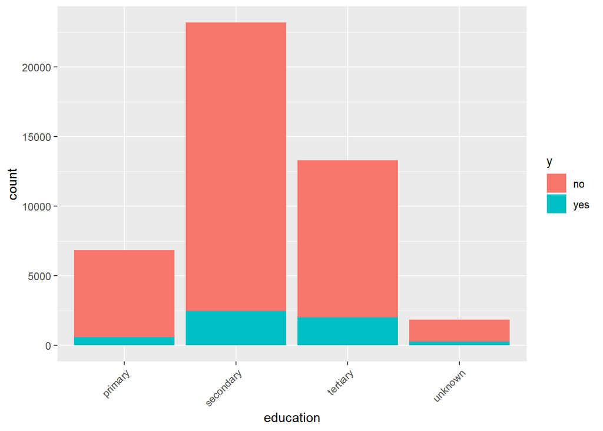

```r
ggplot(df, aes(x = education))+geom_histogram(aes(fill = y), stat = "count")+theme(axis.text.x = element_text(angle = 45, hjust = 1))
```

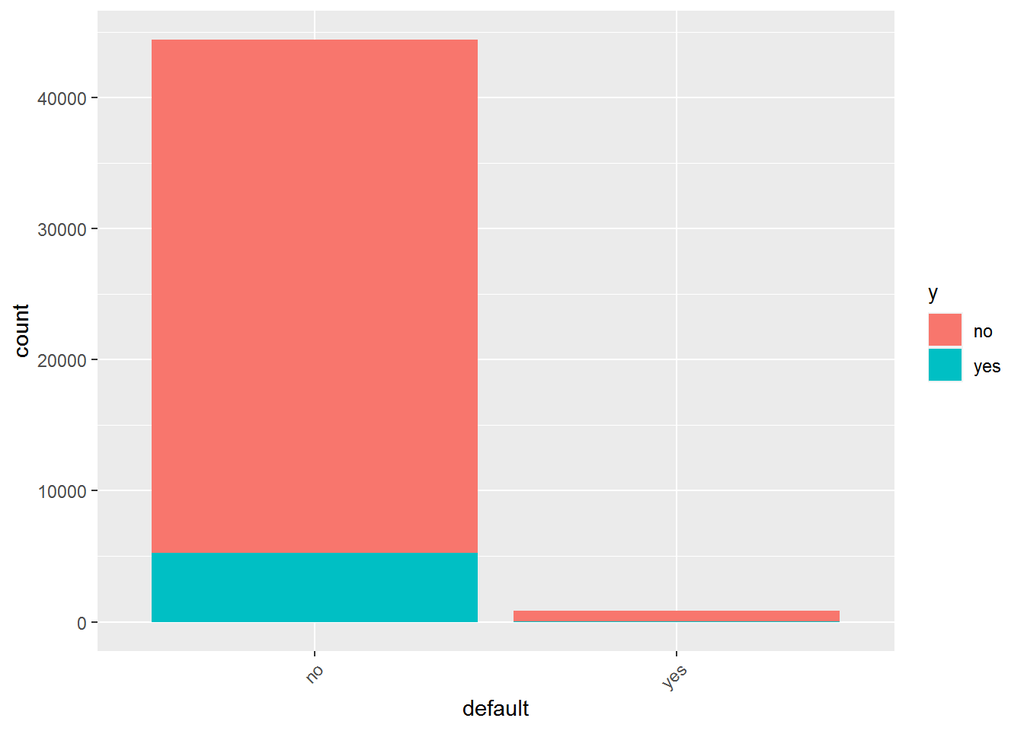

```r
ggplot(df, aes(x = default))+geom_histogram(aes(fill = y), stat = "count")+theme(axis.text.x = element_text(angle = 45, hjust = 1))
```

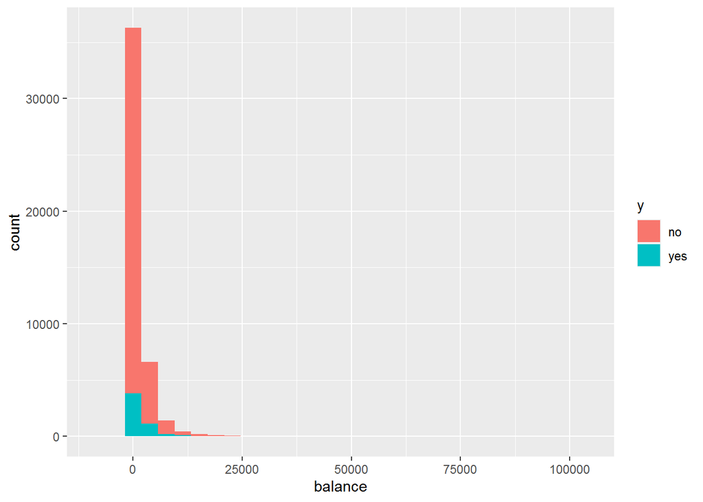

```r
ggplot(df, aes(x = balance))+geom_histogram(aes(fill = y))
```

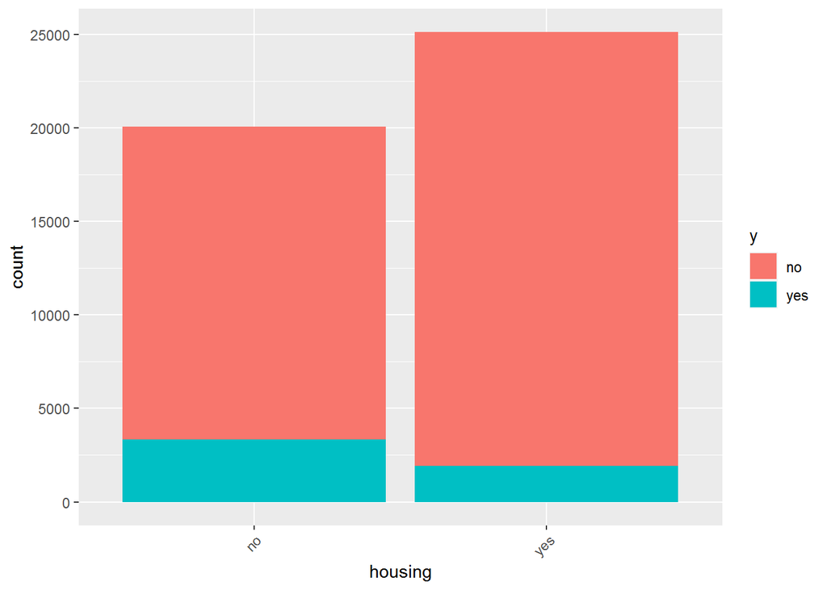

```r
ggplot(df, aes(x = housing))+geom_histogram(aes(fill = y), stat = "count")+theme(axis.text.x = element_text(angle = 45, hjust = 1))
```

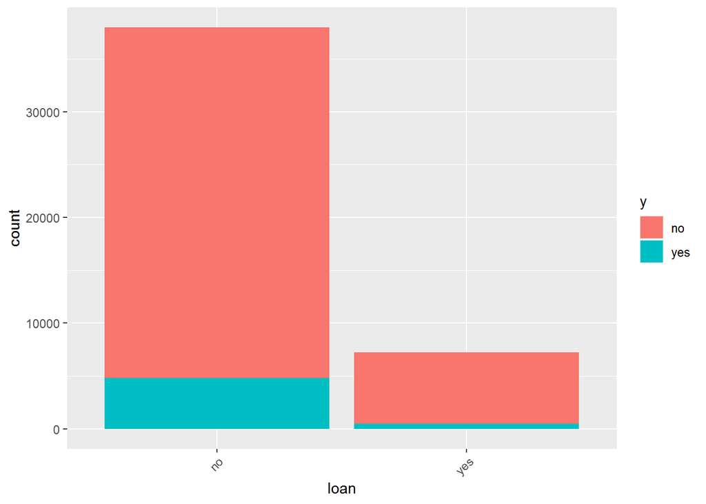

```r
ggplot(df, aes(x = loan))+geom_histogram(aes(fill = y), stat = "count")+theme(axis.text.x = element_text(angle = 45, hjust = 1))
```

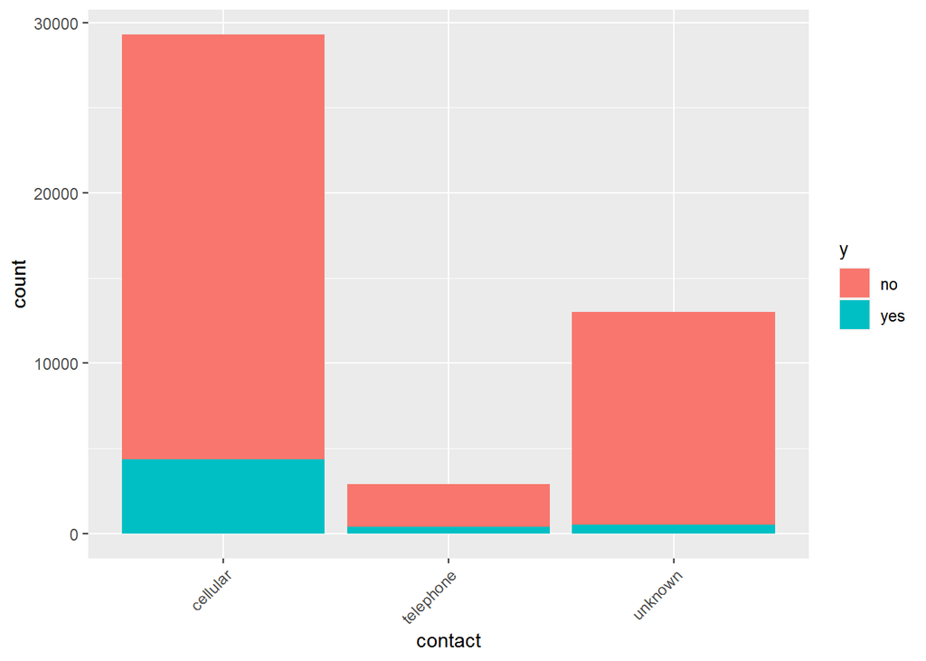

```r
ggplot(df, aes(x = contact))+geom_histogram(aes(fill = y), stat = "count")+theme(axis.text.x = element_text(angle = 45, hjust = 1))
```

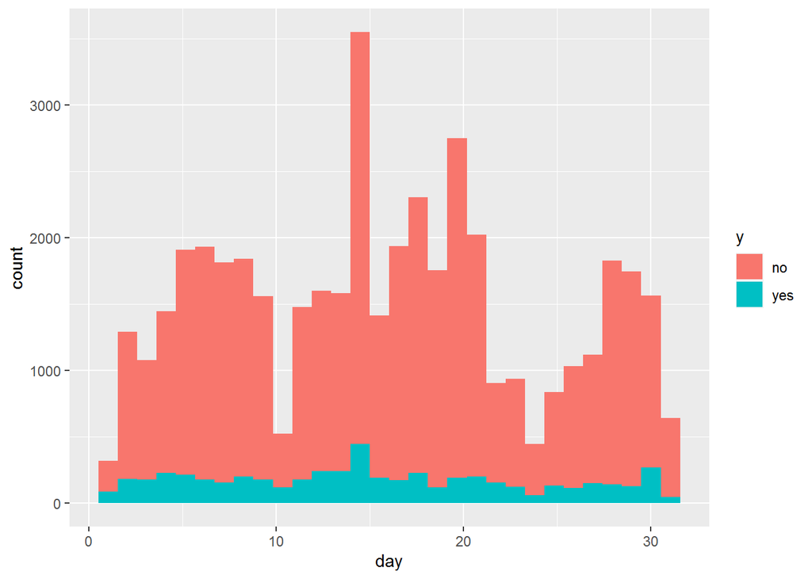

```r
ggplot(df, aes(x = day))+geom_histogram(aes(fill = y))
```

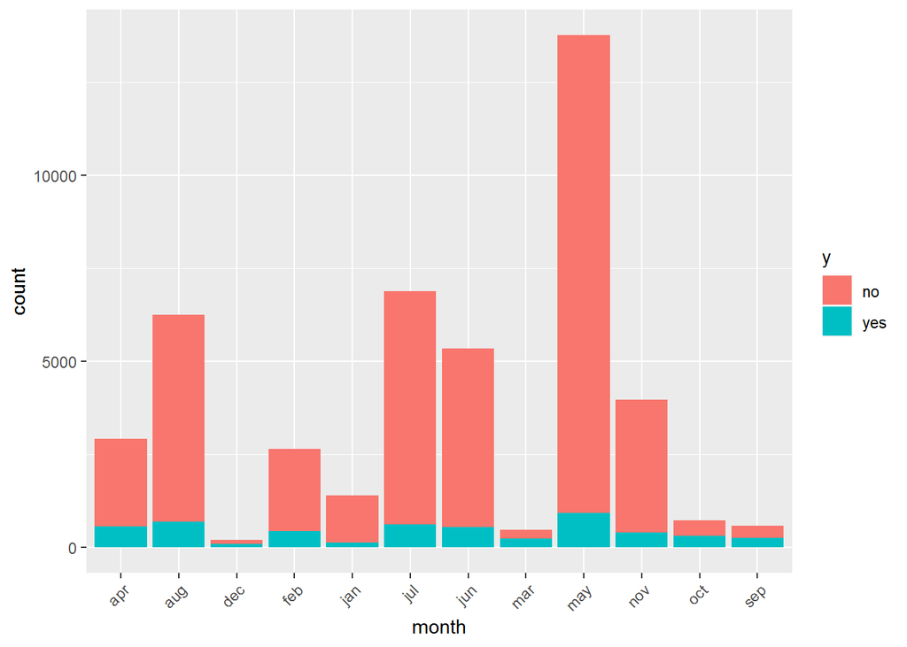

```r
ggplot(df, aes(x = month))+geom_histogram(aes(fill = y), stat = "count")+theme(axis.text.x = element_text(angle = 45, hjust = 1))
```

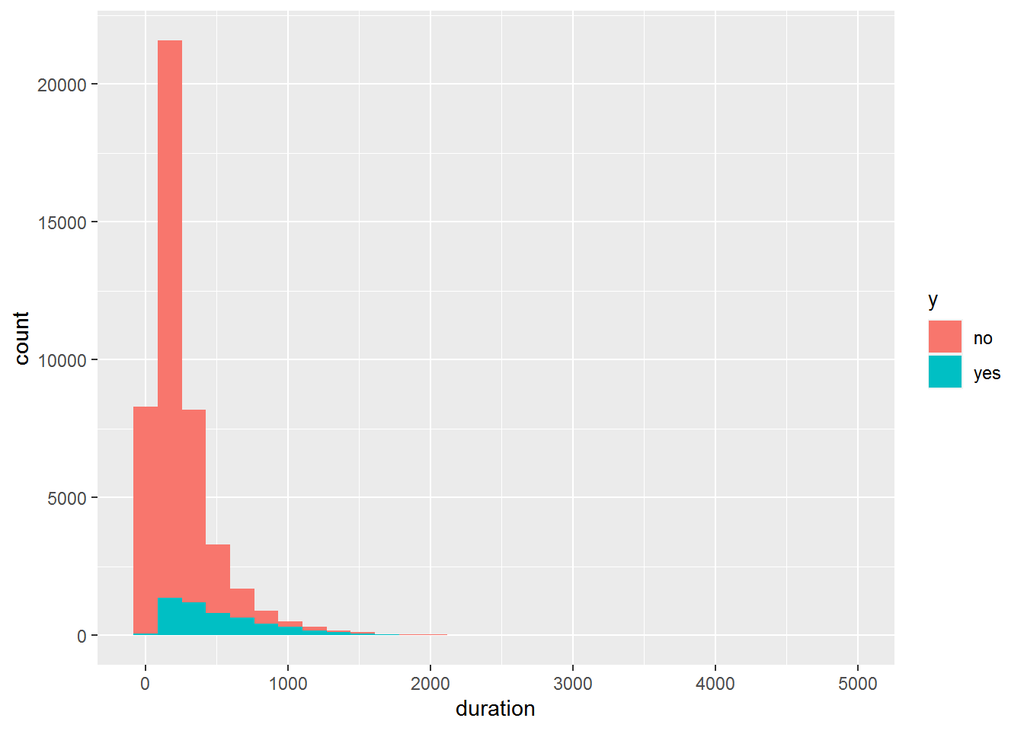

```r
ggplot(df, aes(x = duration))+geom_histogram(aes(fill = y))
```

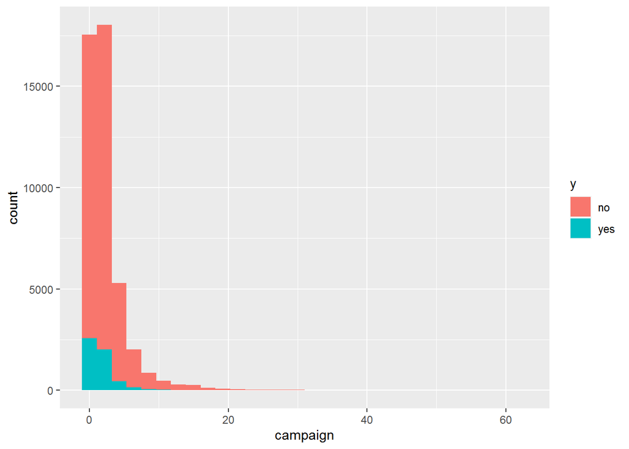

```r
ggplot(df, aes(x = campaign))+geom_histogram(aes(fill = y))
```

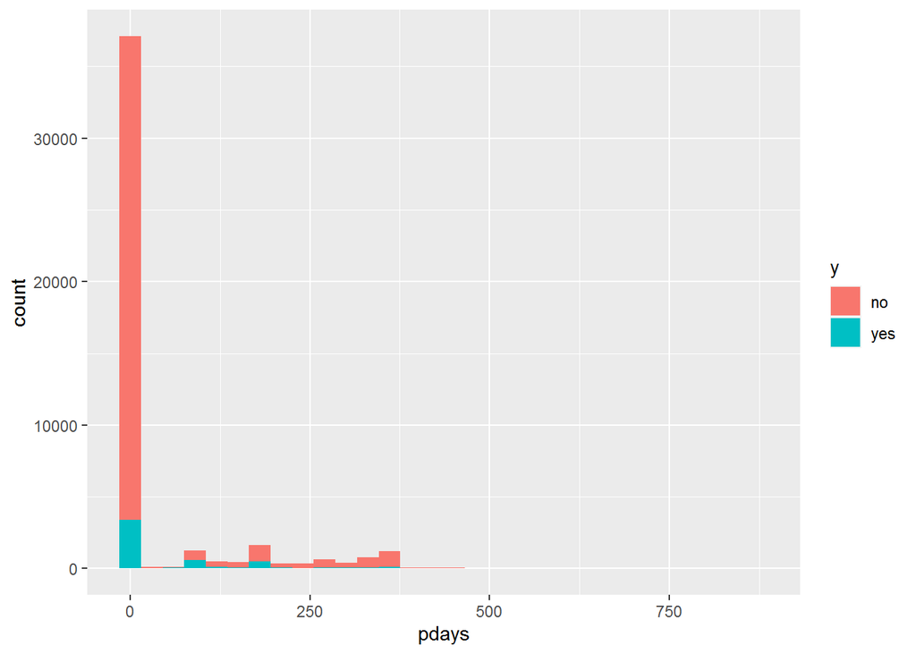

```r
ggplot(df, aes(x = pdays))+geom_histogram(aes(fill = y))
```

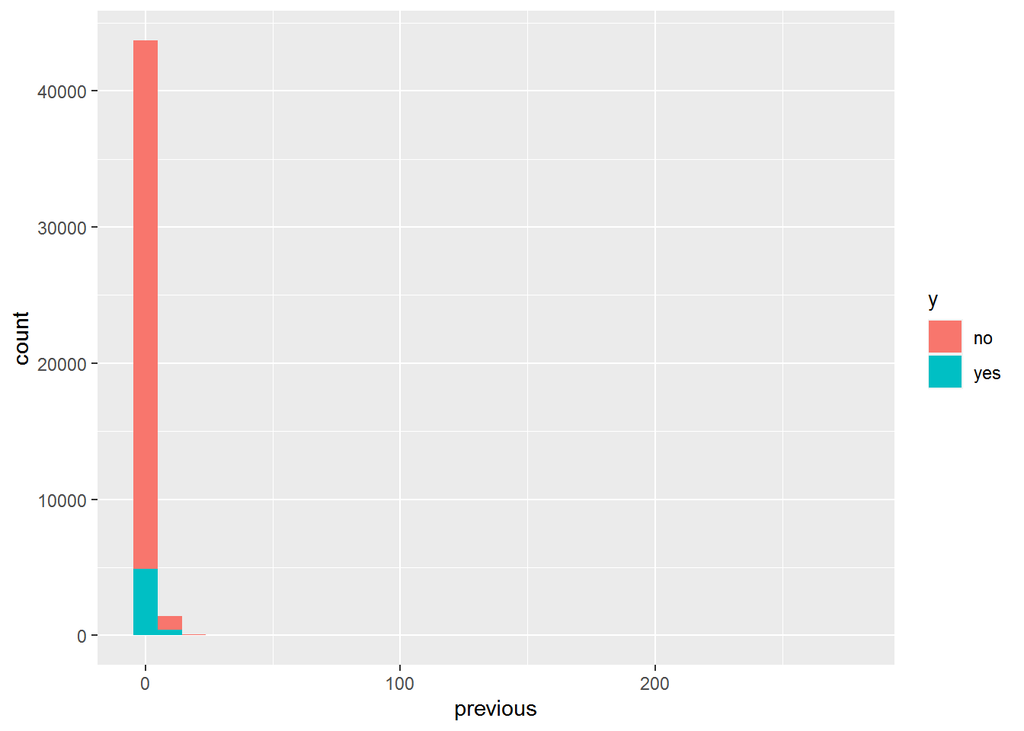

```r
ggplot(df, aes(x = previous))+geom_histogram(aes(fill = y))
```

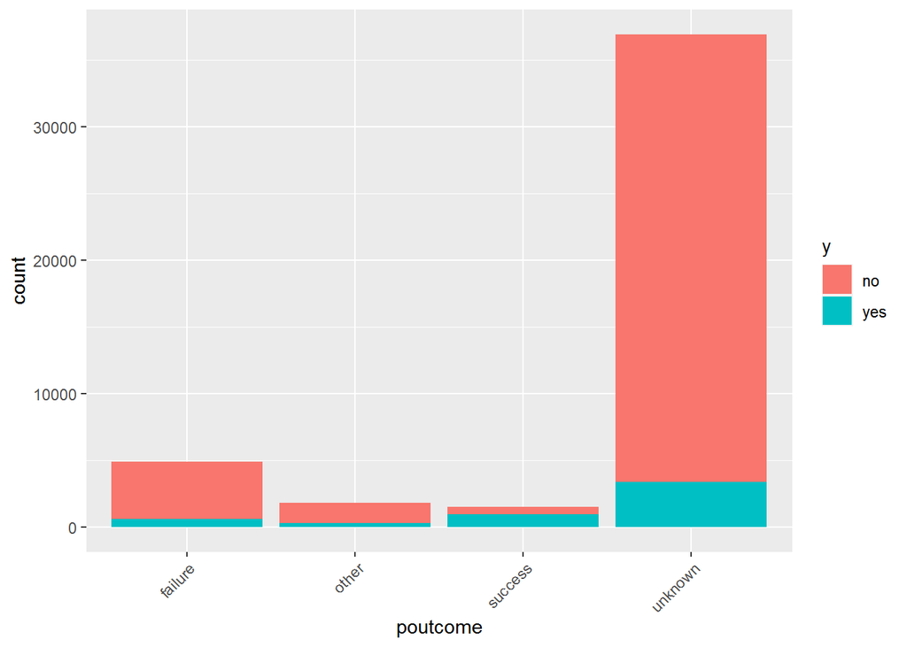

```r
ggplot(df, aes(x = poutcome))+geom_histogram(aes(fill = y), stat = "count")+theme(axis.text.x = element_text(angle = 45, hjust = 1))
```

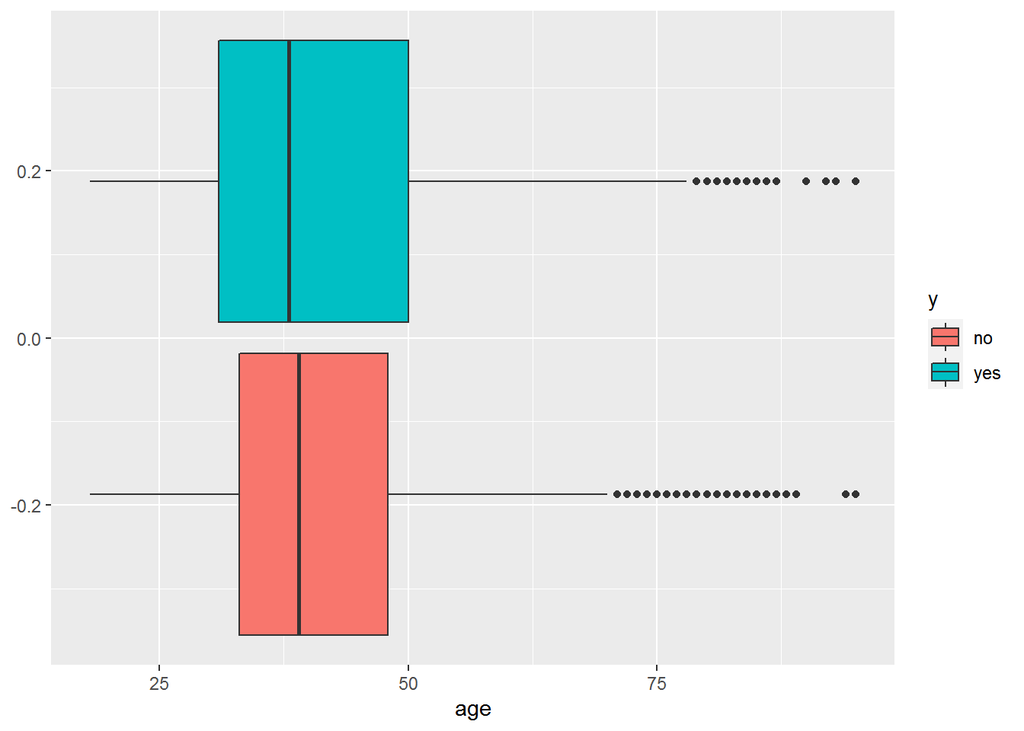

```r
ggplot(df, aes(x = age))+geom_boxplot(aes(fill = y))
```

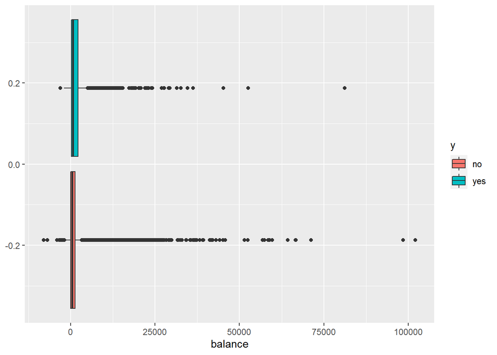

```r
ggplot(df, aes(x = balance))+geom_boxplot(aes(fill = y))
```

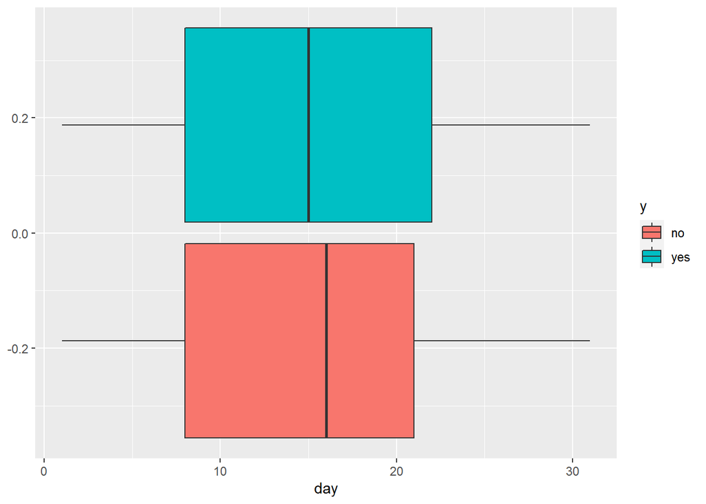

```r
ggplot(df, aes(x = day))+geom_boxplot(aes(fill = y))
```

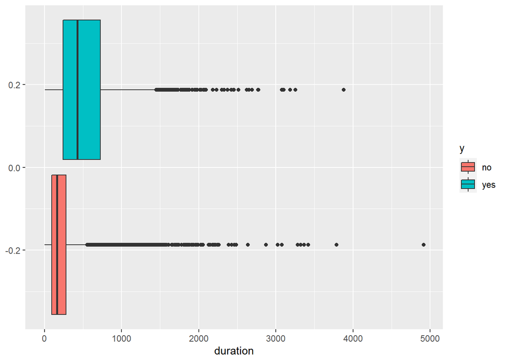

```r
ggplot(df, aes(x = duration))+geom_boxplot(aes(fill = y))
```

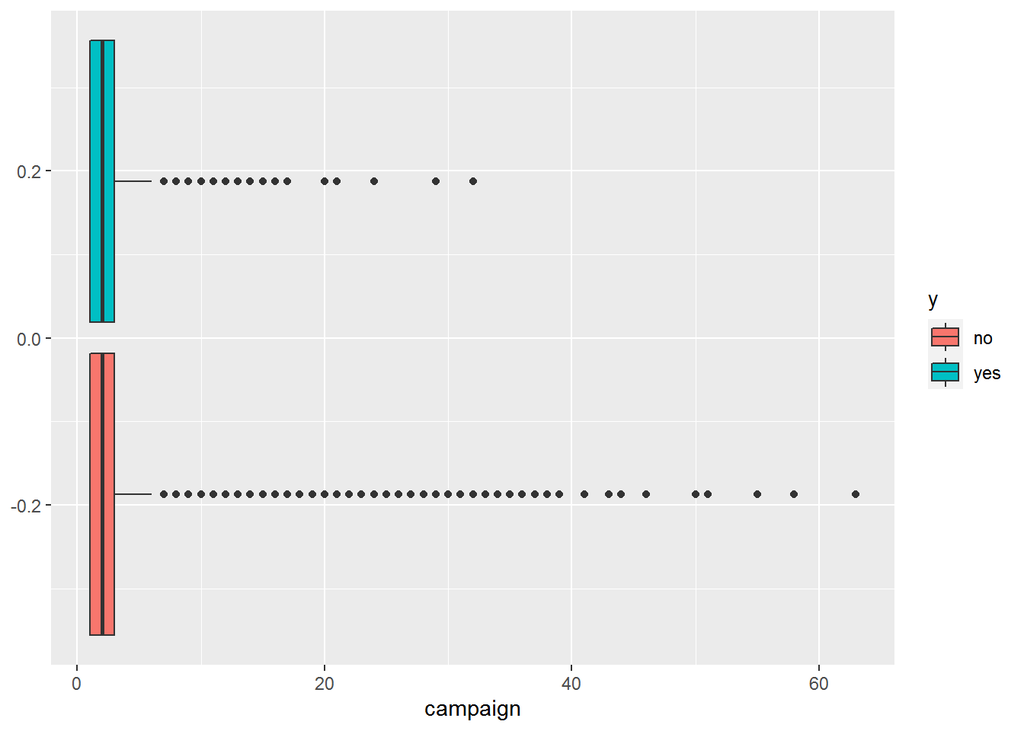

```r
ggplot(df, aes(x = campaign))+geom_boxplot(aes(fill = y))
```

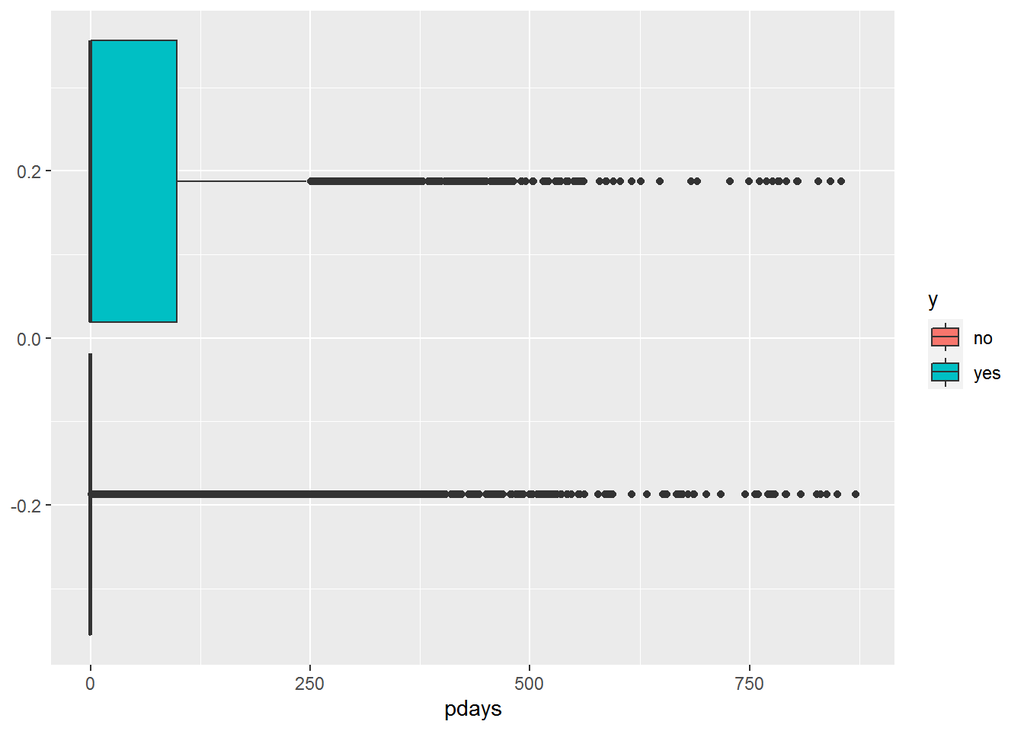

```r
ggplot(df, aes(x = pdays))+geom_boxplot(aes(fill = y))
```

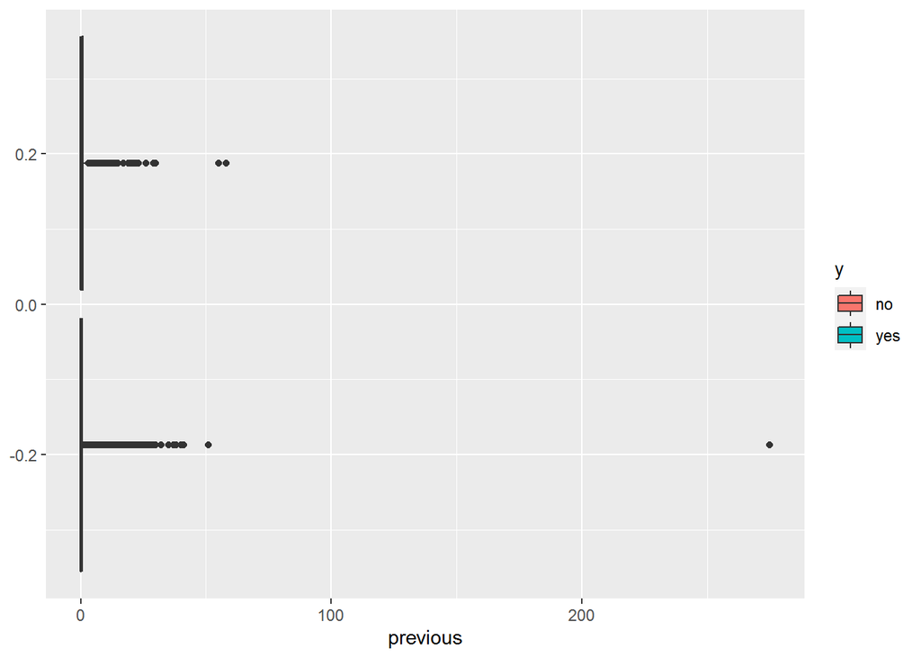

```r
ggplot(df, aes(x = previous))+geom_boxplot(aes(fill = y))
```

En cuanto a agrupación de factores y modificación de variables categóricas se refiere, si nos fijamos en la variable ‘job’ vemos que se puede agrupar según la naturaleza del trabajo en si son autónomos, no son autónomos o que no trabajan. Pasamos a la variable poutcome, donde vamos a convertirla en binaria según si ha habido exito o no.

```r
df$job <- gsub('^retired', 'no_job', df$job)
df$job <- gsub('^unemployed', 'no_job', df$job)
df$job <- gsub('^unknown', 'no_job', df$job)
df$job <- gsub('^housemaid', 'no_job', df$job)
df$job <- gsub('^student', 'no_job', df$job)
df$job <- gsub('^entrepreneur', 'self_employed', df$job)
df$job <- gsub('^self-employed', 'self_employed', df$job)
df$job <- gsub('^admin.', 'with_job', df$job)
df$job <- gsub('^blue-collar', 'with_job', df$job)
df$job <- gsub('^management', 'with_job', df$job)
df$job <- gsub('^services', 'with_job', df$job)
df$job <- gsub('^technician', 'with_job', df$job)
df$job <- factor(df$job)

summary(df$job)
```

```
##        no_job self_employed      with_job
##          6033          3066         36112
```

```r
df$month <- df$month %>% match(tolower(month.abb))

df$poutcome <- gsub('^failure', 'no_success', df$poutcome)
df$poutcome <- gsub('^other', 'no_success', df$poutcome)
df$poutcome <- gsub('^unknown', 'no_success', df$poutcome)
df$poutcome <- factor(df$poutcome)

summary(df$poutcome)
```

```
## no_success    success
##      43700       1511
```

Ahora pasamos a ver las correlaciones de las variables numéricas y estudiar su asimetría. Como podemos ver, todas presentan una fuerte asimetría ya que sus valores son mayor a 0.7. También observamos correlación entre ‘pdays’ y ‘previous’, podemos incurrir a problemas de multicolinealidad por lo que prescindiremos de ‘pdays’. Las modificaciones a estos problemas las llevaremos acabo mediante “recipes” más adelante.

```r
vars_num <- df %>% select(balance, duration, campaign, pdays, previous) %>% names()

for (i in vars_num){
print(df[,i] %>% moments::skewness())
}
```

```
## [1] 8.360031
## [1] 3.144214
## [1] 4.898488
## [1] 2.615629
## [1] 41.84507
```

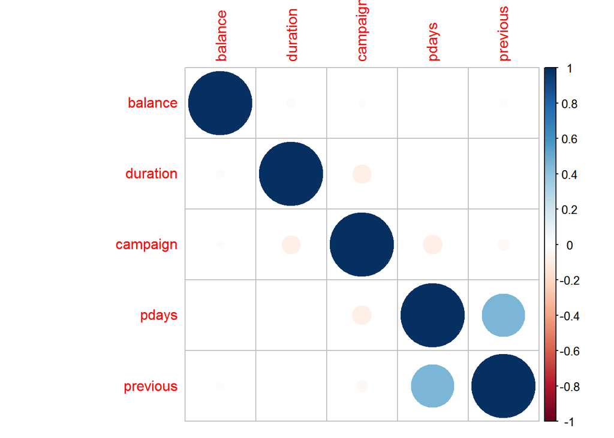

```r
corrplot(corr = cor(df[,vars_num]))
```

## 3. Tratamiento outliers

```r
vars_num <- df %>% select(balance, duration, campaign, pdays, previous) %>% names()

for (i in vars_num){
qnt <- quantile(df[i]%>%purrr::as_vector(), probs=c(.1, .9))
caps <- quantile(df[i]%>%purrr::as_vector(), probs=c(.1, .9))
H <- IQR(df[i] %>% purrr::as_vector())
df[i][df[i] < (qnt[1] - H)] <- caps[1]
df[i][df[i] > (qnt[2] + H)] <- caps[2]
}
```

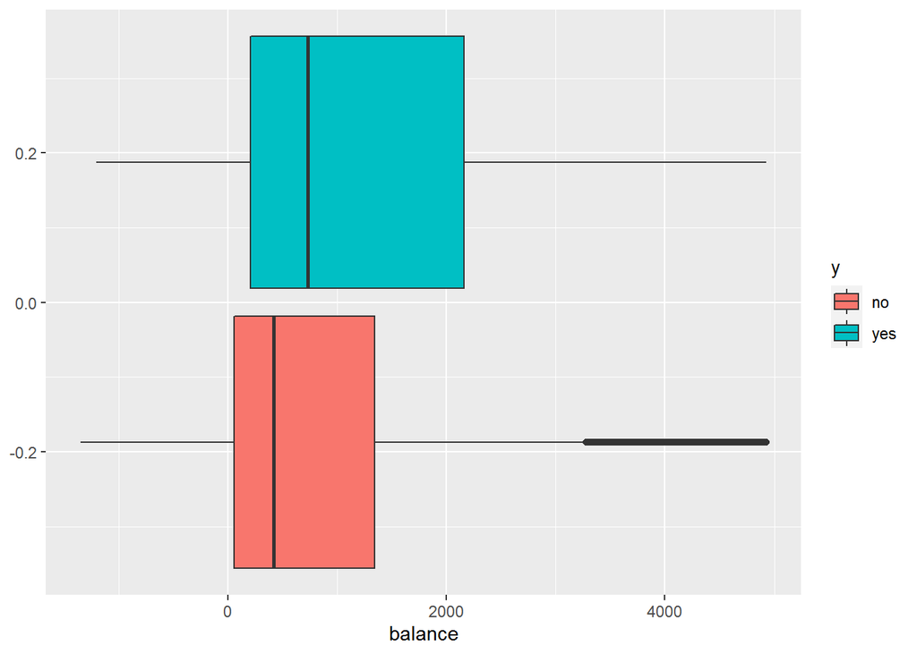

```r
ggplot(df, aes(x = balance))+geom_boxplot(aes(fill = y))
```

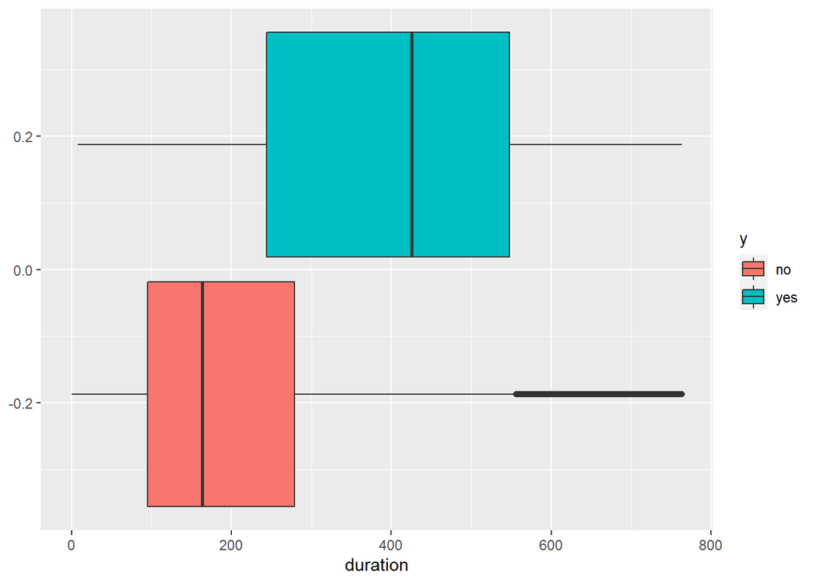

```r
ggplot(df, aes(x = duration))+geom_boxplot(aes(fill = y))
```

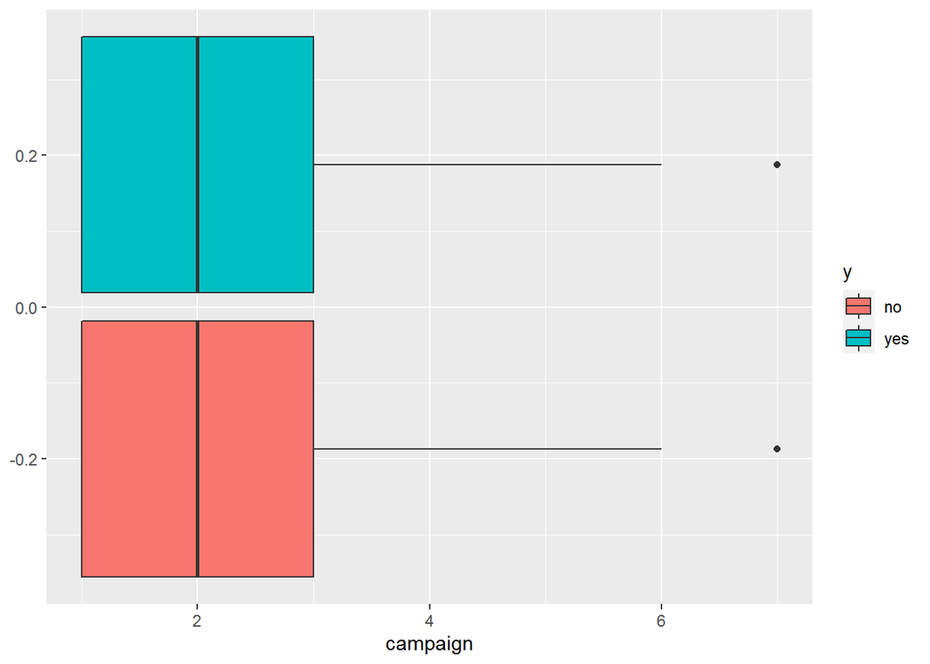

```r
ggplot(df, aes(x = campaign))+geom_boxplot(aes(fill = y))
```

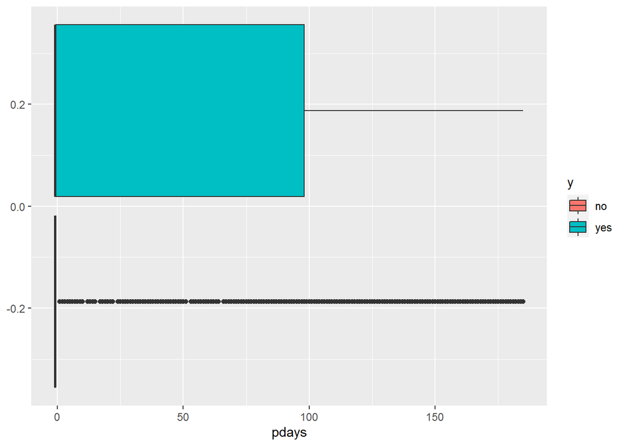

```r
ggplot(df, aes(x = pdays))+geom_boxplot(aes(fill = y))
```

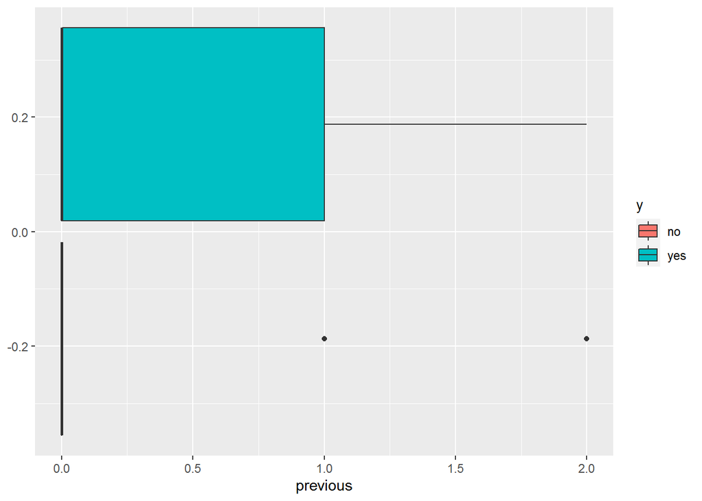

```r
ggplot(df, aes(x = previous))+geom_boxplot(aes(fill = y))
```

## 4. Preprocesado con Recipes

En este apartado llevaremos a cabo todo el preprocesamiento en cuanto a feature engineering se refiere gracias a “recipes”, que permite una forma clara, ordenada, limpia y efectiva de tratar los datos. Primero pasamos a plantar una semilla y a dividir entre training y test los datos.

```r
set.seed(2020)

split <- createDataPartition(df$y, p = 0.7, list = TRUE)

df_train <- df[split$Resample1,]
df_test <- df[-split$Resample1,]
```

Vamos a graficar las variables ‘duration’ y ‘balance’ para ver la transformación que ejecutamos más detalladamente.

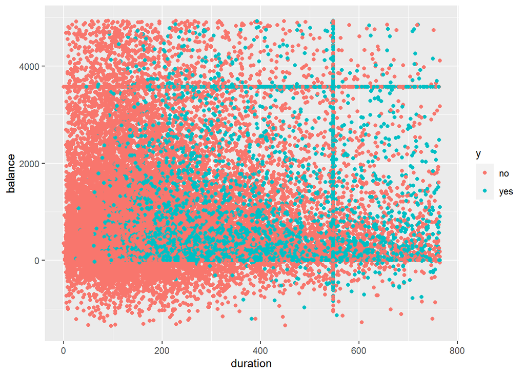

```r
ggplot(df_train, aes(x = duration, y = balance, color = y))+geom_point()
```

### 4.1. Creacion del recipe.

Pasamos a aplicar “recipes”. Los recipes son como una receta de cocina, donde tu vas indicando los pasos a seguir para preparar el plato. Se empieza indicando como debe ser el recipe en forma de formula tipo un modelo lineal básico. A continuación, vamos indicando los ingredientes de la receta a traves de cada step. Posteriormente nos valemos de la función prep, para aplicar el recipe al conjunto de entrenamiento. Al conjunto de test lo transformaremos a través de la función bake. Si queremos ver como queda finalmente el conjunto de train tenemos que aplicar la funcion juice al recipe preparado.

Pasamos a ver los pasos aplicados:

- Primero eliminaremos variables que puedan inducir a multicolinealidad con un threshold de 0.7.
- Seguimos aplicando logaritmos a las variables numericas, ya que hemos visto antes que todas eran asimétricas. Importante dejar signed en TRUE ya que trata los casos de valores negativos y 0. Alternativamente se podria aplicar una transformación Yeojhonson pero no me ha convencido como finalmente se veian las observaciones ya que se ven más separados con logaritmos.
- Convertimos las categóricas a variables dumy.
- Creamos interacciones entre ‘duration’ y categóricas que he visto que tienen una proporción importante de “si”.
- Posteriormente balanceamos. En este caso, me he decidio por hacer un randomundersampling a la clase mayoritaria, para ganar eficiencia computacional. He probado con métodos de smote+tomek y adasyn+tomek pero todos los métodos presentan resultados similares.
- El siguiente paso es medir la distancia Mahalanobis entre clases con su centroide.
- Finalmente lo normalizamos todo.

Creamos los folds de validación cruzada y ya tenemos todos los ingredientes listos y preparados para cocinar.

```r
set.seed(2020)
recipe <- recipe(y ~., data = df_train) %>%
  step_corr(all_numeric(), threshold = 0.7) %>%
  step_log(all_numeric(), signed = TRUE) %>%
  #step_YeoJohnson(all_numeric()) %>%
  step_dummy(all_nominal(), -y) %>%
  step_interact(terms = ~housing_yes*duration) %>%
  step_interact(terms = ~poutcome_success*duration) %>%
  #step_adasyn(y, over_ratio = 1, neighbors = 100, skip = TRUE, seed = 2020) %>%
  #step_bsmote(y, over_ratio = 1, neighbors = 100, skip = TRUE, seed = 2020) %>%
  #step_tomek(y, skip = TRUE) %>%
  step_downsample(y, under_ratio = 1, skip = TRUE, seed = 2020) %>%
  step_classdist(all_predictors(), class = "y", log = TRUE) %>%
  step_center(all_predictors()) %>%
  step_scale(all_predictors()) %>%
  step_range(all_predictors())

df_train_recipe <- prep(recipe, training = df_train)

summary(df_train_recipe)
```

```
## # A tibble: 25 x 4
##    variable          type    role      source
##    <chr>             <chr>   <chr>     <chr>
##  1 age               numeric predictor original
##  2 balance           numeric predictor original
##  3 day               numeric predictor original
##  4 month             numeric predictor original
##  5 duration          numeric predictor original
##  6 campaign          numeric predictor original
##  7 previous          numeric predictor original
##  8 y                 nominal outcome   original
##  9 job_self_employed numeric predictor derived
## 10 job_with_job      numeric predictor derived
## # ... with 15 more rows
```

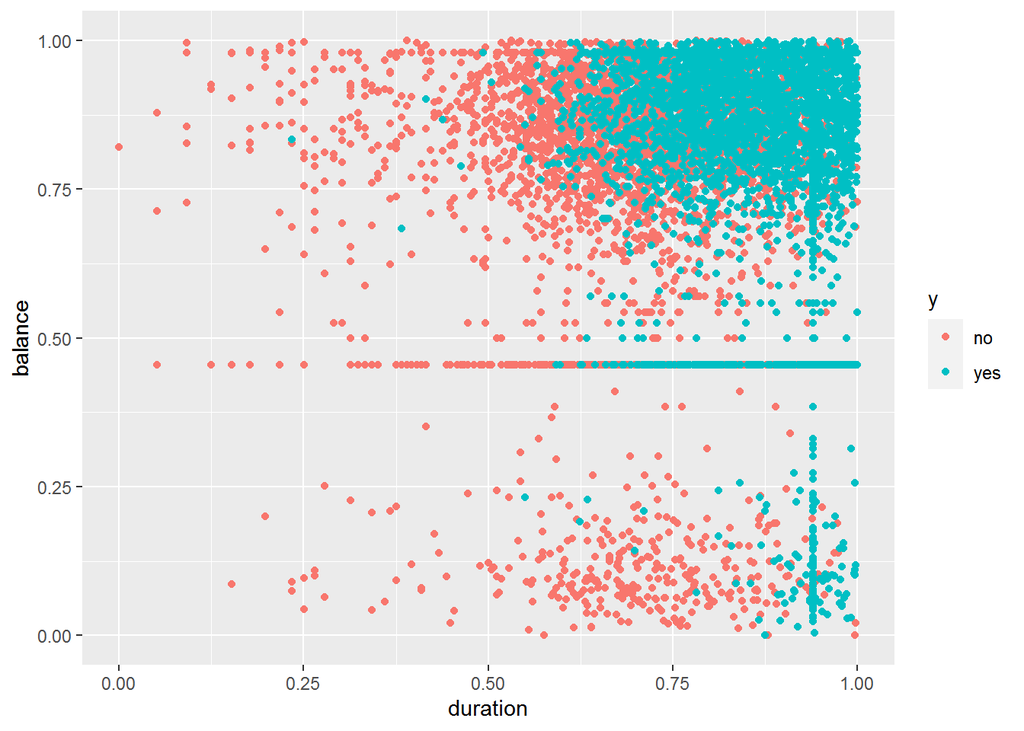

```r
df_test_recipe <- bake(df_train_recipe, new_data = df_test, everything())

df_train_recipe %>%
  juice() %>%
  ggplot(aes(x = duration, y = balance, color = y))+
  geom_point()
```

```r
cv_folds <- caret::createFolds(df_train_recipe %>% juice %>% .$y, k = 5, list = TRUE)
```

## 5. Modelos

En este apartado es donde se cocina el plato a través de los modelos. Empezamos creando la función para las métricas a optimizar. La llamaremos ‘metrics’ y en ella hallaremos la Precision, Recall y la F1. Nos vamos a centrar en optimizar la F1 debido a que ‘y’ padecía de un fuerte desbalanceo. Este desbalanceo provoca que la Accuracy no sea apropiada para optimizar debido a que los modelos tenderian a sesgar sus predicciones hacia la clase mayoritaria para obtener la maxima accuracy, en cambio la F1 hace la media harmónica de la Precision y la Recall con lo cual nos puede proporcionar resultados que se adaptan mejor a nuestro problema al dar más importancia a los False Positive y los False Negative.

$$\begin{array}
{rrr}
& Reference \\
Predicted & Event & No Event \\
Event & A & B \\
No Event & C & D \\
\end{array}$$

- $Accuracy: A+D/A+B+C+D$
- $Precision = A/(A+B)$
- $Recall = A/(A+C)$
- $F1 = (1+beta^2) * precision * recall/((beta^2 * precision)+recall)$ *beta = 1 será nuestro caso

```r
metrics <- function(data, lev = NULL, model = NULL){
  precision_res <- caret::precision(data$pred, data$obs, relevant = "yes")
  recall_res <- caret::recall(data$pred, data$obs, relevant = "yes")
  f1_res <- caret::F_meas(data$pred, data$obs, relevant = "yes", beta = 1)
  names(precision_res) <- c("Precision")
  names(recall_res) <- c("Recall")
  names(f1_res) <- c("F1")
  c(precision_res, recall_res, f1_res)
}
```

Nos vamos a valer de la libreria caret para entrenar los modelos ya que presenta una estructura sencilla y clara para la busqueda de hiperparámetros, y la aplicación de la validación cruzada. Entonces, entrenaremos los modelos contenidos en ‘models’, en la que entrenaremos una amplia variedad.

He calculado también ‘weights’ para el caso que hubieramos decidido no balancear el trainingset y quisieramos aplicar costes.

Decidimos entrenar de cada tipo de algoritmo 5 modelos para la optimizacion de hiperparametros.

Finalmente como la métrica elegida es la F1, evaluaremos que tan buenos clasificadores de la clase “yes” tenemos. Se podría hacer también desde el punto de vista de la clase “no” pero creo que es más interesante el enfoque desde la clase minoritaria.

```r
set.seed(2020)
# Training

models = c("glm", 'svmPoly', 'svmRadial', 'svmLinear', "glmnet", "naive_bayes", "rpart", "ranger", "xgbTree")
num_model = 5

weights <- as.numeric(df_train_recipe %>% juice %>% .$y)

for(val in unique(weights)){
  weights[weights==val] <- 1/sum(weights==val)*length(weights)/2
}


modelos <- list()
y_pred <- list()
results <- list()

  for (i in models){

    control <- trainControl(
        search = "random",
        verboseIter = T,
        savePredictions = "final",
        classProbs = T,
        summaryFunction = metrics,
        method = "cv",
        index = cv_folds
        )

    modelos[[i]] <- train(y~.
      , data = df_train_recipe %>% juice
      #, weights =  weights
      , method = i
      , trControl = control
      , metric = "F1"
      , tuneLength = num_model
       )

    y_pred[[i]] <- predict(modelos[[i]], df_test_recipe %>% select(-y))
    results[[i]] <- caret::confusionMatrix(y_pred[[i]], df_test_recipe$y, positive = "yes", mode = "prec_recall")

  }
```

```
## line search fails -0.2846349 -0.04300548 2.94967e-05 1.26081e-07 -9.315568e-09 -1.987664e-09 -2.750291e-13
```

```
## Fitting nrounds = 651, max_depth = 10, eta = 0.248, gamma = 3.49, colsample_bytree = 0.375, min_child_weight = 0, subsample = 0.878 on full training set
```

Una vez hemos entrenado los modelos, podemos evaluarlos sobre el conjunto test. Abajo podemos ver sus puntuaciones.

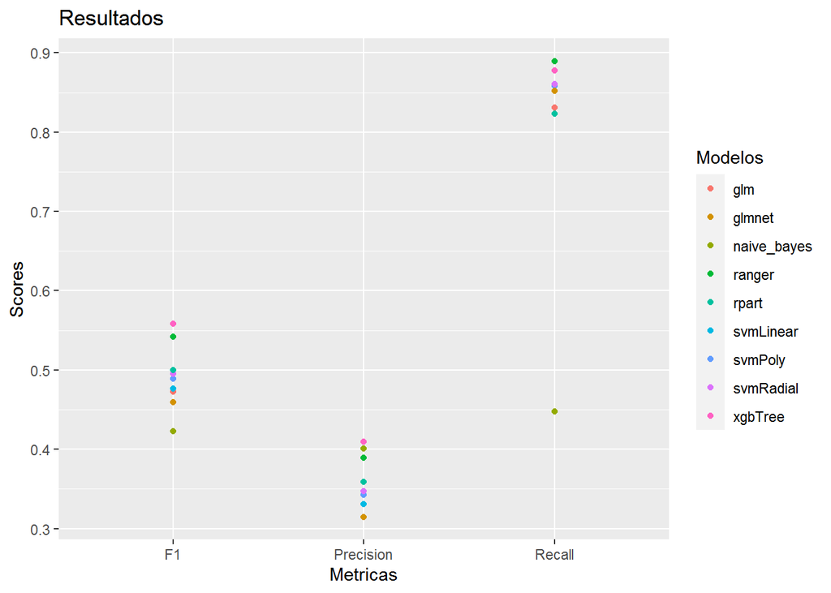

```r
# Resultados

results %>%
  map(.f = pluck("byClass")) %>%
  map(magrittr::extract, c("Precision", "Recall", "F1")) %>%
  data.frame() %>%
  t() %>%
  data.frame() %>%
  mutate(Modelos = rownames(.)) %>%
  pivot_longer(-Modelos, names_to = "Metricas", values_to = "Scores") %>%
  ggplot(mapping = (aes(x = Metricas, y = Scores, color = Modelos)))+
    geom_point()+
    theme_grey()+
    ggtitle("Resultados")
```

Veamos la matriz de confusión de nuestro mejor modelo. Efectivamente, vemos como es capaz de reconocer un buen porcentage de la clase “yes” (lo que seria la Recall), pero es a costa de una baja precision de sus predicciones a la clase “yes” ya que su porcentage no es muy bueno (Precision). Entonces la F1 pondera esas dos metricas por igual y nos deja su puntuación en un 0,55.

```r
results$xgbTree
```

```
## Confusion Matrix and Statistics
##
##           Reference
## Prediction   no  yes
##        no  9970  194
##        yes 2006 1392
##
##                Accuracy : 0.8378
##                  95% CI : (0.8315, 0.844)
##     No Information Rate : 0.8831
##     P-Value [Acc > NIR] : 1
##
##                   Kappa : 0.4748
##
##  Mcnemar's Test P-Value : <2e-16
##
##               Precision : 0.4097
##                  Recall : 0.8777
##                      F1 : 0.5586
##              Prevalence : 0.1169
##          Detection Rate : 0.1026
##    Detection Prevalence : 0.2506
##       Balanced Accuracy : 0.8551
##
##        'Positive' Class : yes
##
```

### 5.1. Stacking

Como no acabamos de estar muy satisfechos con esta F1, intentaremos ver si la podemos mejorar mediante la técnica de stacking, que consiste en combinar varios modelos entre si. Gracias a las fortalezas de cada uno se consiguen compensar las debilidades respectivas obteniendo asi una posible mejora en la performance. Para conseguir un buen stacking es importante que los modelos seleccionados tengan una correlación baja entre sí, ya que de lo contrario obtendremos los resultados del mejor modelo de todos u otros suboptimos y eso es algo que ya tenemos y no nos interesa.

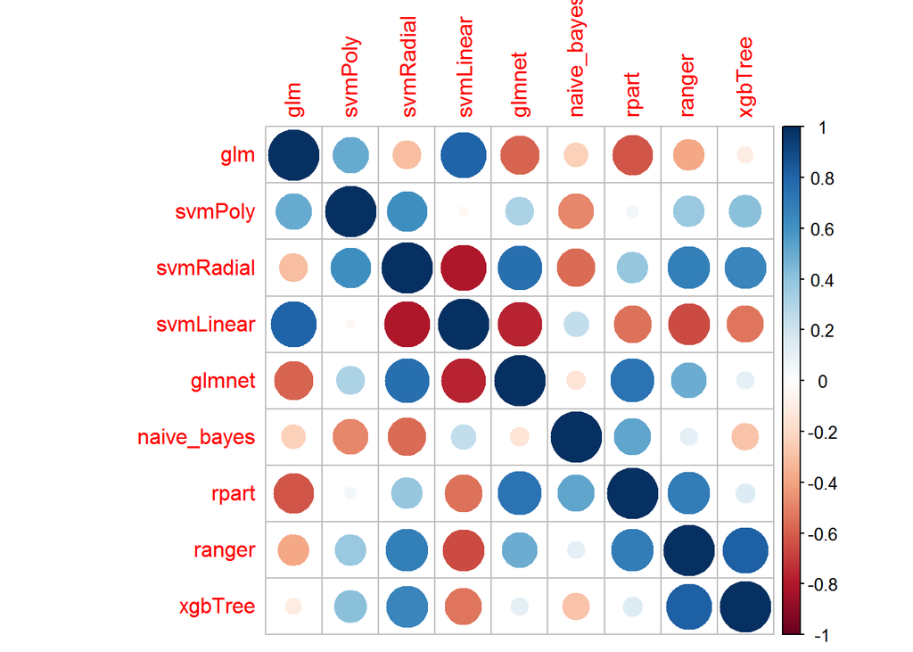

```r
modelCor(resamples(modelos)) %>% corrplot()
```

Una vez estudiadas las correlaciones, los pasos a seguir para elaborar nuestro modelo de stacking son los siguientes:

1. Entrenar los modelos de la primera capa. (Ya lo hemos hecho arriba)
2. Hacer predicciones sobre el conjunto de test y obtener asi el conjunto de test para el stacking. (Las predicciones ya las tenemos hechas)
3. De los modelos entrenados, extraer las predicciones de validación cruzada del conjunto de entrenamiento. Así tenemos el conjunto de entramiento que usaremos para entrenar el modelo de stacking, osea la segunda capa.
4. Entrenar stack y hacer predicciones. Finalmente evaluar.

Entonces, la estructura del stacking constará de la capa inicial o clasificadores débiles de ‘xgbTree’, ‘naive_bayes’ y ‘rpart’. En la segunda capa un simple ‘glm’ como clasificador final.

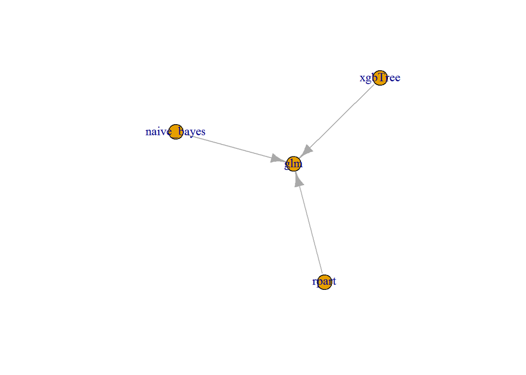

```r
make_graph(edges = c('xgbTree', 'glm', 'naive_bayes', 'glm', 'rpart', 'glm')) %>% plot()
```

```r
set.seed(2020)
# Creamos listas vacias que seran los conjuntos de entrenamiento y test del stack.

df_train_stack <- list()
y_pred_prob <- list()


# Obtenemos las predicciones de validacion cruzada de los modelos seleccionados para el stacking.

for (i in models[models %in% c("xgbTree", "naive_bayes", "rpart")]){
  df_train_stack[[i]] <- modelos[[i]][["pred"]] %>% arrange(rowIndex, Resample) %>% .$yes
  y_pred_prob[[i]] <- predict(modelos[[i]], df_test_recipe %>% select(-y), type = "prob") %>% .$yes
}


# Convertimos las listas y añadimos la variable objetivo a predecir a cada conjunto.

df_train_stack <- df_train_stack %>%
  data.frame(y = modelos[["xgbTree"]][["pred"]] %>% arrange(rowIndex, Resample) %>% .$obs) %>%
  as_tibble()

df_test_stack <- y_pred_prob %>%
  data.frame(y = df_test_recipe$y) %>%
  as_tibble()

control2 <- trainControl(
        search = "random",
        verboseIter = T,
        savePredictions = "final",
        classProbs = T,
        summaryFunction = metrics,
        method = "cv",
        number = 5
        )

stack <- train(y~.
      , data = df_train_stack
      , method = "glm"
      , trControl = control2
      , metric = "F1"
      , tuneLength = 5
       )
y_pred_stack <- predict(stack,
                        df_test_stack %>%
                          select(-y))
results_stack <- caret::confusionMatrix(y_pred_stack,
                                        df_test_stack$y,
                                        positive = "yes",
                                        mode = "prec_recall")
results_stack
```

```
## Confusion Matrix and Statistics
##
##           Reference
## Prediction    no   yes
##        no  10002   204
##        yes  1974  1382
##
##                Accuracy : 0.8394
##                  95% CI : (0.8331, 0.8455)
##     No Information Rate : 0.8831
##     P-Value [Acc > NIR] : 1
##
##                   Kappa : 0.4761
##
##  Mcnemar's Test P-Value : <2e-16
##
##               Precision : 0.4118
##                  Recall : 0.8714
##                      F1 : 0.5593
##              Prevalence : 0.1169
##          Detection Rate : 0.1019
##    Detection Prevalence : 0.2475
##       Balanced Accuracy : 0.8533
##
##        'Positive' Class : yes
##
```

Analizando los resultados vemos como hemos conseguido mejorar un poquito la F1 gracias al poder del Stacking.